# Homework 6

PSTAT 131/231

## Tree-Based Models

```r
rm(list = ls())
```

For this assignment, we will continue working with the file `"pokemon.csv"`, found in `/data`. The file is from Kaggle: https://www.kaggle.com/abcsds/pokemon.

The [Pokémon](https://www.pokemon.com/us/) franchise encompasses video games, TV shows, movies, books, and a card game. This data set was drawn from the video game series and contains statistics about 721 Pokémon, or “pocket monsters.” In Pokémon games, the user plays as a trainer who collects, trades, and battles Pokémon to (a) collect all the Pokémon and (b) become the champion Pokémon trainer.

Each Pokémon has a [primary type](https://bulbapedia.bulbagarden.net/wiki/Type) (some even have secondary types). Based on their type, a Pokémon is strong against some types, and vulnerable to others. (Think rock, paper, scissors.) A Fire-type Pokémon, for example, is vulnerable to Water-type Pokémon, but strong against Grass-type.

The goal of this assignment is to build a statistical learning model that can predict the **primary type** of a Pokémon based on its generation, legendary status, and six battle statistics.

**Note: Fitting ensemble tree-based models can take a little while to run. Consider running your models outside of the .Rmd, storing the results, and loading them in your .Rmd to minimize time to knit.**

```r
library(tidyverse)
library(tidymodels)
library(ISLR)
library(vip)
library(janitor)
library(randomForest)
library(xgboost)
library(ggplot2)
library(corrr)
```

### Exercise 1

Read in the data and set things up as in Homework 5:

- Use `clean_names()`
- Filter out the rarer Pokémon types
- Convert `type_1` and `legendary` to factors

Do an initial split of the data; you can choose the percentage for splitting. Stratify on the outcome variable.

Fold the training set using *v*-fold cross-validation, with `v = 5`. Stratify on the outcome variable.

Set up a recipe to predict `type_1` with `legendary`, `generation`, `sp_atk`, `attack`, `speed`, `defense`, `hp`, and `sp_def`:

- Dummy-code `legendary` and `generation`;
- Center and scale all predictors.

```r
pokemon<-read.csv("/Users/xuao/Documents/2022Fall/Pstat131/PSTAT231/homework-6/data/Pokemon.csv")
pokemon<-clean_names(pokemon)

pokemon<-pokemon %>%
  filter(type_1 %in% c("Bug","Fire","Grass","Normal","Water","Psychic"))
pokemon$type_1<-factor(pokemon$type_1)
pokemon$legendary<-factor(pokemon$legendary)

pokemon_split <- initial_split(pokemon, prop = 0.80, strata = type_1)
pokemon_train <- training(pokemon_split)
pokemon_test <- testing(pokemon_split)

pokemon_folds <- vfold_cv(pokemon_train, v = 5, strata=type_1)
pokemon_recipe <- recipe(type_1 ~ legendary + generation + sp_atk + attack + speed + defense + hp + sp_def,
                         data = pokemon_train) %>%
  step_dummy(legendary,generation) %>%
  step_center(all_predictors()) %>%
  step_scale(all_predictors())
```

### Exercise 2

Create a correlation matrix of the training set, using the `corrplot` package. *Note: You can choose how to handle the continuous variables for this plot; justify your decision(s).*

What relationships, if any, do you notice? Do these relationships make sense to you?

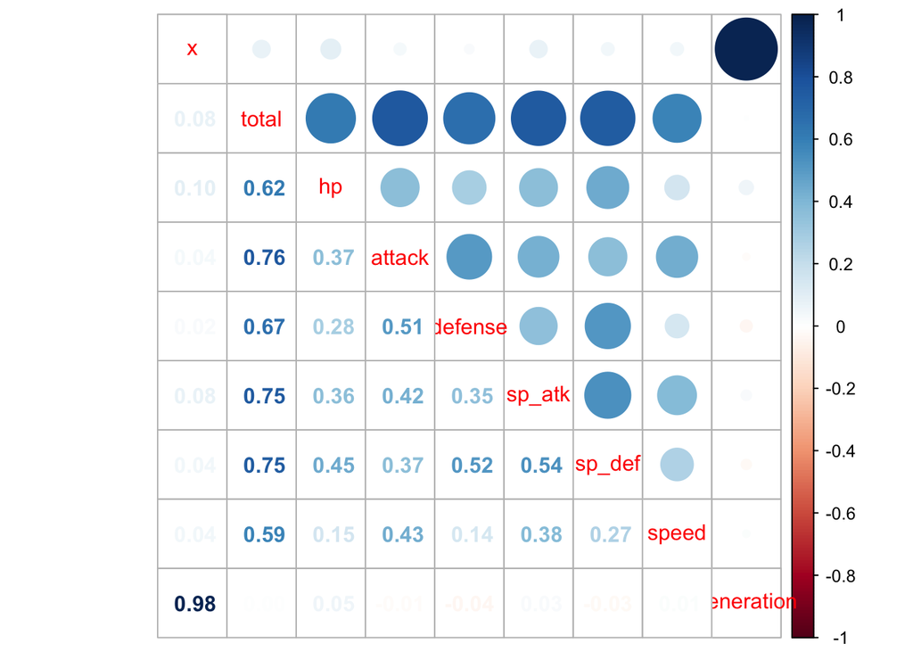

```r
library(corrplot)
cor_pokemon_train <- pokemon_train %>%
  select(where(is.numeric)) %>%
  cor(use = "pairwise.complete.obs", method = "pearson")
corrplot.mixed(cor_pokemon_train)
```

Not really, I am wondering why (1) attack and total (2) sp_atk and total are highly-correlated but attack and sp_atk are not highly-correaletd.

### Exercise 3

First, set up a decision tree model and workflow. Tune the `cost_complexity` hyperparameter. Use the same levels we used in Lab 7 – that is, `range = c(-3, -1)`. Specify that the metric we want to optimize is `roc_auc`.

Print an `autoplot()` of the results. What do you observe? Does a single decision tree perform better with a smaller or larger complexity penalty?

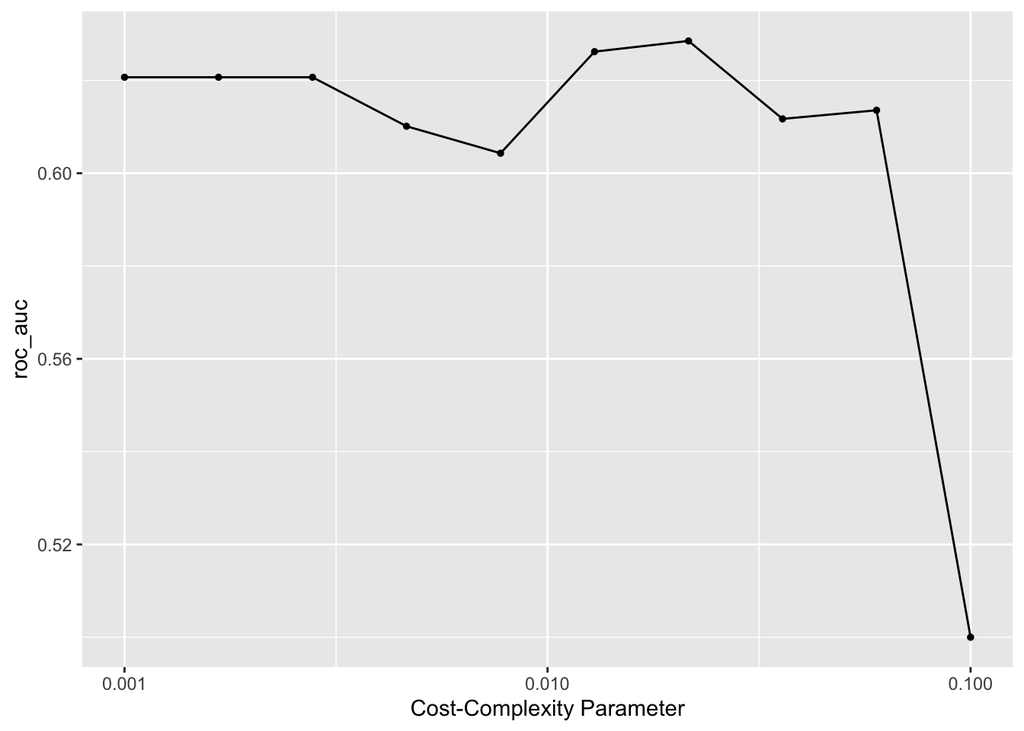

```r
tree_spec<-decision_tree() %>%
  set_engine("rpart")
class_tree_spec<-tree_spec %>%
  set_mode("classification")

tree_workflow <-workflow() %>%
  add_model(class_tree_spec %>% set_args(cost_complexity=tune())) %>%
  add_recipe(pokemon_recipe)

set.seed(2888)
pokemon_folds <- vfold_cv(pokemon_train)
param_grid <- grid_regular(cost_complexity(range = c(-3, -1)),levels=10)

tune_res <- tune_grid(
  tree_workflow,
  resamples=pokemon_folds,
  grid=param_grid,
  metrics=metric_set(roc_auc)
)
autoplot(tune_res)
```

### Exercise 4

What is the `roc_auc` of your best-performing pruned decision tree on the folds? *Hint: Use `collect_metrics()` and `arrange()`.*

```r
collect_metrics(tune_res)
```

```
## # A tibble: 10 × 7
##    cost_complexity .metric .estimator  mean     n std_err .config
##              <dbl> <chr>   <chr>      <dbl> <int>   <dbl> <chr>
##  1         0.001   roc_auc hand_till  0.621    10  0.0164 Preprocessor1_Model01
##  2         0.00167 roc_auc hand_till  0.621    10  0.0164 Preprocessor1_Model02
##  3         0.00278 roc_auc hand_till  0.621    10  0.0164 Preprocessor1_Model03
##  4         0.00464 roc_auc hand_till  0.610    10  0.0174 Preprocessor1_Model04
##  5         0.00774 roc_auc hand_till  0.604    10  0.0180 Preprocessor1_Model05
##  6         0.0129  roc_auc hand_till  0.626    10  0.0129 Preprocessor1_Model06
##  7         0.0215  roc_auc hand_till  0.629    10  0.0100 Preprocessor1_Model07
##  8         0.0359  roc_auc hand_till  0.612    10  0.0138 Preprocessor1_Model08
##  9         0.0599  roc_auc hand_till  0.614    10  0.0144 Preprocessor1_Model09
## 10         0.1     roc_auc hand_till  0.5      10  0      Preprocessor1_Model10
```

```r
arrange(tune_res)
```

```
## # Tuning results
## # 10-fold cross-validation
## # A tibble: 10 × 4
##    splits           id     .metrics          .notes
##    <list>           <chr>  <list>            <list>
##  1 <split [327/37]> Fold01 <tibble [10 × 5]> <tibble [1 × 3]>
##  2 <split [327/37]> Fold02 <tibble [10 × 5]> <tibble [1 × 3]>
##  3 <split [327/37]> Fold03 <tibble [10 × 5]> <tibble [1 × 3]>
##  4 <split [327/37]> Fold04 <tibble [10 × 5]> <tibble [1 × 3]>
##  5 <split [328/36]> Fold05 <tibble [10 × 5]> <tibble [1 × 3]>
##  6 <split [328/36]> Fold06 <tibble [10 × 5]> <tibble [1 × 3]>
##  7 <split [328/36]> Fold07 <tibble [10 × 5]> <tibble [1 × 3]>
##  8 <split [328/36]> Fold08 <tibble [10 × 5]> <tibble [1 × 3]>
##  9 <split [328/36]> Fold09 <tibble [10 × 5]> <tibble [1 × 3]>
## 10 <split [328/36]> Fold10 <tibble [10 × 5]> <tibble [1 × 3]>
##
## There were issues with some computations:
##
##   - Warning(s) x10: The following variables are not factor vectors and will be ignore...
##
## Run `show_notes(.Last.tune.result)` for more information.
```

```r
best1 <- select_best(tune_res)
best1
```

```
## # A tibble: 1 × 2
##   cost_complexity .config
##             <dbl> <chr>
## 1          0.0215 Preprocessor1_Model07
```

### Exercise 5

Using `rpart.plot`, fit and visualize your best-performing pruned decision tree with the *training* set.

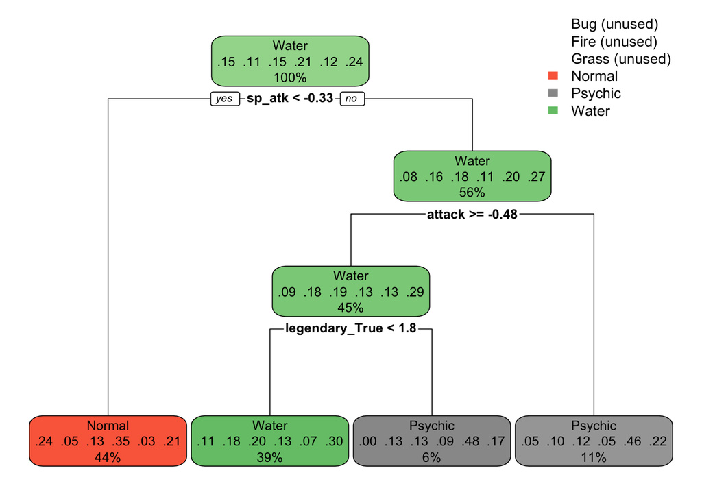

```r
library(rpart.plot)
class_tree_final <- finalize_workflow(tree_workflow,best1)
class_tree_final_fit<-fit(class_tree_final,data=pokemon_train)
class_tree_final_fit %>%
  extract_fit_engine() %>%
  rpart.plot()
```

### Exercise 5

Now set up a random forest model and workflow. Use the `ranger` engine and set `importance = "impurity"`. Tune `mtry`, `trees`, and `min_n`. Using the documentation for `rand_forest()`, explain in your own words what each of these hyperparameters represent.

Create a regular grid with 8 levels each. You can choose plausible ranges for each hyperparameter. Note that `mtry` should not be smaller than 1 or larger than 8. **Explain why not. What type of model would `mtry = 8` represent?**

```r
forest <- rand_forest() %>%
  set_engine("ranger", importance="impurity") %>%
  set_mode("classification") %>%
  set_args(mtry = tune(),trees = tune(), min_n = tune())
forest
```

```
## Random Forest Model Specification (classification)
##
## Main Arguments:
##   mtry = tune()
##   trees = tune()
##   min_n = tune()
##
## Engine-Specific Arguments:
##   importance = impurity
##
## Computational engine: ranger
```

```r
forest_workflow <- workflow() %>%
  add_model(forest %>% set_args(mtry = tune(), trees = tune(),
                                           min_n = tune())) %>%
  add_recipe(pokemon_recipe)
#forest_workflow
param_grid2<-grid_regular(mtry(range = c(1, 8)),
                          trees(range = c(1,8)),
                          min_n(range = c(1,8)),
                          levels = 8)
param_grid2
```

```
## # A tibble: 512 × 3
##     mtry trees min_n
##    <int> <int> <int>
##  1     1     1     1
##  2     2     1     1
##  3     3     1     1
##  4     4     1     1
##  5     5     1     1
##  6     6     1     1
##  7     7     1     1
##  8     8     1     1
##  9     1     2     1
## 10     2     2     1
## # … with 502 more rows
```

Mtry is number of predictors.

Trees is the number of trees.

Min_n is integer for the minimum number of data points.

`mtry` should not be smaller than 1 or larger than 8 since there is at least one predictor but at most 8 predictors.

If `mtry` = 8, then it means that all predictors are used.

### Exercise 6

Specify `roc_auc` as a metric. Tune the model and print an `autoplot()` of the results. What do you observe? What values of the hyperparameters seem to yield the best performance?

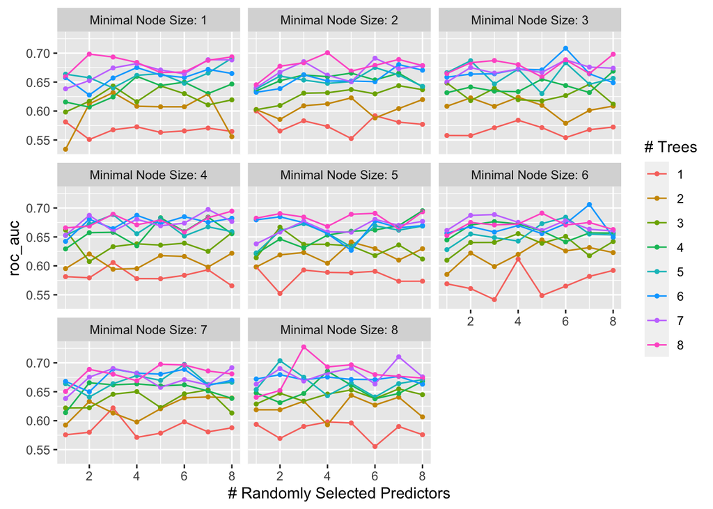

```r
#install.packages("ranger")
tune_res_forest<-tune_grid(
  forest_workflow,
  resamples = pokemon_folds,
  grid = param_grid2,
  metrics = metric_set(roc_auc)
)
autoplot(tune_res_forest)
```

### Exercise 7

What is the `roc_auc` of your best-performing random forest model on the folds? *Hint: Use `collect_metrics()` and `arrange()`.*

```r
collect_metrics(tune_res_forest) %>%
  arrange(desc(mean))
```

```
## # A tibble: 512 × 9
##     mtry trees min_n .metric .estimator  mean     n std_err .config
##    <int> <int> <int> <chr>   <chr>      <dbl> <int>   <dbl> <chr>
##  1     3     8     8 roc_auc hand_till  0.727    10  0.0147 Preprocessor1_Model…
##  2     7     7     8 roc_auc hand_till  0.710    10  0.0155 Preprocessor1_Model…
##  3     6     6     3 roc_auc hand_till  0.708    10  0.0224 Preprocessor1_Model…
##  4     7     6     6 roc_auc hand_till  0.706    10  0.0161 Preprocessor1_Model…
##  5     2     5     8 roc_auc hand_till  0.704    10  0.0131 Preprocessor1_Model…
##  6     4     8     2 roc_auc hand_till  0.701    10  0.0164 Preprocessor1_Model…
##  7     2     8     1 roc_auc hand_till  0.698    10  0.0236 Preprocessor1_Model…
##  8     8     8     3 roc_auc hand_till  0.698    10  0.0136 Preprocessor1_Model…
##  9     5     8     7 roc_auc hand_till  0.698    10  0.0142 Preprocessor1_Model…
## 10     7     7     4 roc_auc hand_till  0.698    10  0.0207 Preprocessor1_Model…
## # … with 502 more rows
```

```r
best2<-select_best(tune_res_forest)
best2
```

```
## # A tibble: 1 × 4
##    mtry trees min_n .config
##   <int> <int> <int> <chr>
## 1     3     8     8 Preprocessor1_Model507
```

### Exercise 8

Create a variable importance plot, using `vip()`, with your best-performing random forest model fit on the *training* set.

Which variables were most useful? Which were least useful? Are these results what you expected, or not?

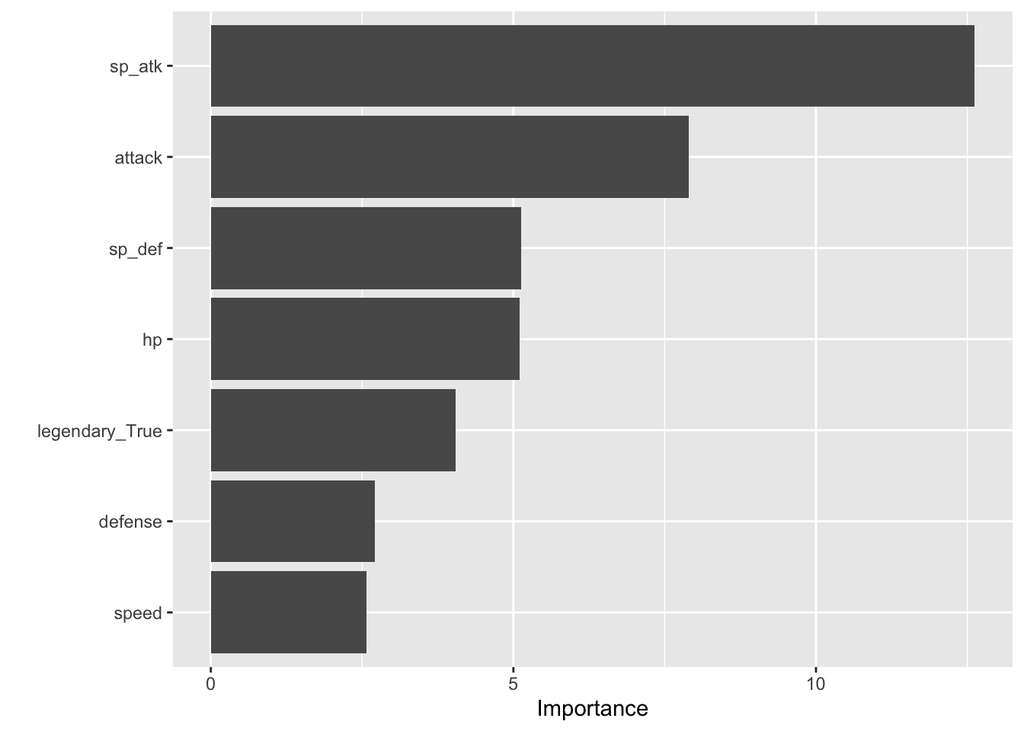

```r
class_tree_final_fit %>%
  pull_workflow_fit() %>%
  vip()
```

### Exercise 9

Finally, set up a boosted tree model and workflow. Use the `xgboost` engine. Tune `trees`. Create a regular grid with 10 levels; let `trees` range from 10 to 2000. Specify `roc_auc` and again print an `autoplot()` of the results.

What do you observe?

What is the `roc_auc` of your best-performing boosted tree model on the folds? *Hint: Use `collect_metrics()` and `arrange()`.*

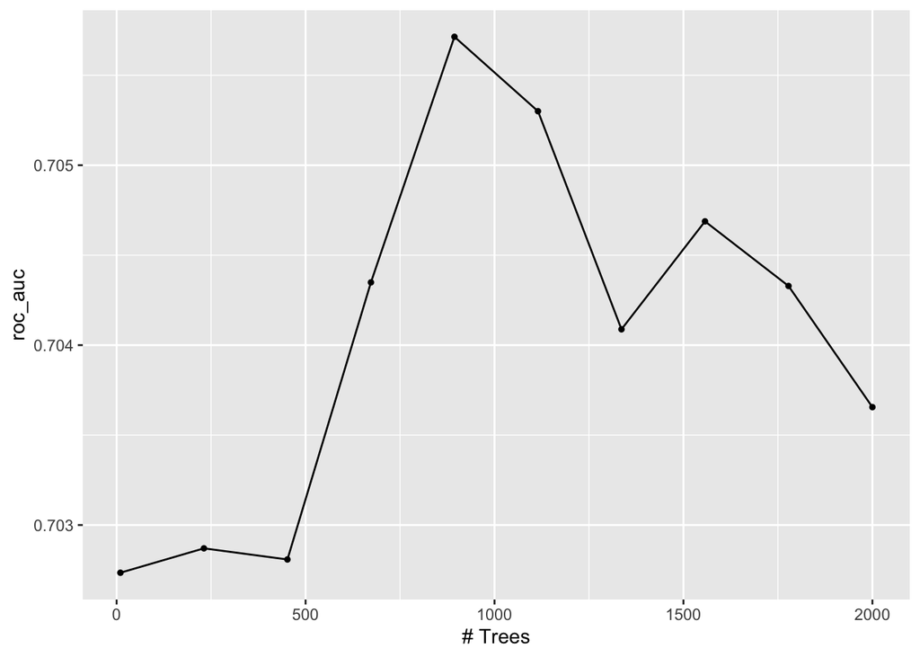

```r
boost_spec <- boost_tree(trees = c(10,2000), tree_depth = 4) %>%
  set_engine("xgboost") %>%
  set_mode("classification")
param_grid_boost <- grid_regular(trees(range = c(10, 2000)),  levels = 10)

boost_workflow <- workflow() %>%
  add_model(boost_spec %>% set_args(trees = tune())) %>%
  add_recipe(pokemon_recipe)

tune_res_boost <- tune_grid(
  boost_workflow,
  resamples = pokemon_folds,
  grid = param_grid_boost,
  metrics = metric_set(roc_auc)
)

autoplot(tune_res_boost)
```

```r
collect_metrics(tune_res_boost)
```

```
## # A tibble: 10 × 7
##    trees .metric .estimator  mean     n std_err .config
##    <int> <chr>   <chr>      <dbl> <int>   <dbl> <chr>
##  1    10 roc_auc hand_till  0.703    10  0.0204 Preprocessor1_Model01
##  2   231 roc_auc hand_till  0.703    10  0.0217 Preprocessor1_Model02
##  3   452 roc_auc hand_till  0.703    10  0.0215 Preprocessor1_Model03
##  4   673 roc_auc hand_till  0.704    10  0.0201 Preprocessor1_Model04
##  5   894 roc_auc hand_till  0.706    10  0.0197 Preprocessor1_Model05
##  6  1115 roc_auc hand_till  0.705    10  0.0190 Preprocessor1_Model06
##  7  1336 roc_auc hand_till  0.704    10  0.0189 Preprocessor1_Model07
##  8  1557 roc_auc hand_till  0.705    10  0.0187 Preprocessor1_Model08
##  9  1778 roc_auc hand_till  0.704    10  0.0184 Preprocessor1_Model09
## 10  2000 roc_auc hand_till  0.704    10  0.0179 Preprocessor1_Model10
```

```r
arrange(tune_res_boost)
```

```
## # Tuning results
## # 10-fold cross-validation
## # A tibble: 10 × 4
##    splits           id     .metrics          .notes
##    <list>           <chr>  <list>            <list>
##  1 <split [327/37]> Fold01 <tibble [10 × 5]> <tibble [1 × 3]>
##  2 <split [327/37]> Fold02 <tibble [10 × 5]> <tibble [1 × 3]>
##  3 <split [327/37]> Fold03 <tibble [10 × 5]> <tibble [1 × 3]>
##  4 <split [327/37]> Fold04 <tibble [10 × 5]> <tibble [1 × 3]>
##  5 <split [328/36]> Fold05 <tibble [10 × 5]> <tibble [1 × 3]>
##  6 <split [328/36]> Fold06 <tibble [10 × 5]> <tibble [1 × 3]>
##  7 <split [328/36]> Fold07 <tibble [10 × 5]> <tibble [1 × 3]>
##  8 <split [328/36]> Fold08 <tibble [10 × 5]> <tibble [1 × 3]>
##  9 <split [328/36]> Fold09 <tibble [10 × 5]> <tibble [1 × 3]>
## 10 <split [328/36]> Fold10 <tibble [10 × 5]> <tibble [1 × 3]>
##
## There were issues with some computations:
##
##   - Warning(s) x10: The following variables are not factor vectors and will be ignore...
##
## Run `show_notes(.Last.tune.result)` for more information.
```

```r
best3<-select_best(tune_res_boost)
best3
```

```
## # A tibble: 1 × 2
##   trees .config
##   <int> <chr>
## 1   894 Preprocessor1_Model05
```

### Exercise 10

Display a table of the three ROC AUC values for your best-performing pruned tree, random forest, and boosted tree models. Which performed best on the folds? Select the best of the three and use `select_best()`, `finalize_workflow()`, and `fit()` to fit it to the *testing* set.

Print the AUC value of your best-performing model on the testing set. Print the ROC curves. Finally, create and visualize a confusion matrix heat map.

Which classes was your model most accurate at predicting? Which was it worst at?

```r
library(pROC)
# pruned tree
tree_final <- finalize_workflow(tree_workflow, best1)
tree_final_fit <- fit(class_tree_final, data = pokemon_test)

# random forest
random_forest_tree_final <- finalize_workflow(forest_workflow, best2)
rf_fit <- fit(random_forest_tree_final, data = pokemon_test)

# boosted tree
rand_tree_final <- finalize_workflow(boost_workflow, best3)
boost_fit <- fit(rand_tree_final, data = pokemon_test)

# auc and ROC curve


# roc_auc
tree_fit <- augment(tree_final_fit,
                         new_data = pokemon_test,
                         type = "prob") %>%
  mutate(type_1 = as.factor(type_1)) %>%
  roc_auc(truth = type_1, .pred_Bug:.pred_Water)

rand_tree_fit <- augment(rf_fit,
                         new_data = pokemon_test,
                         type = "prob") %>%
  mutate(type_1 = as.factor(type_1)) %>%
  roc_auc(truth = type_1, .pred_Bug:.pred_Water)

boost_model_fit <- augment(boost_fit,
                         new_data = pokemon_test,
                         type = "prob") %>%
  mutate(type_1 = as.factor(type_1)) %>%
  roc_auc(truth = type_1, .pred_Bug:.pred_Water)

matrix_rocauc <- bind_rows("ROC_AUC for the Best pruned tree model"= tree_fit,"ROC_AUC for the Best Random Forest model"=rand_tree_fit,"ROC_AUC for the Best Boosted model"=boost_model_fit,.id="model")
matrix_rocauc
```

```
## # A tibble: 3 × 4
##   model                                    .metric .estimator .estimate
##   <chr>                                    <chr>   <chr>          <dbl>
## 1 ROC_AUC for the Best pruned tree model   roc_auc hand_till      0.840
## 2 ROC_AUC for the Best Random Forest model roc_auc hand_till      0.971
## 3 ROC_AUC for the Best Boosted model       roc_auc hand_till      1
```

## For 231 Students

### Exercise 11

```r
# Reading the data, tidying the data and setting the recipe as in homework-2
abalone <- read.csv("/Users/xuao/Documents/2022Fall/Pstat131/PSTAT231/homework-6/data/abalone.csv")
abalone$age <- abalone$ring+1.5
set.seed(1888)
abalone_not_ring <- subset(abalone, select = -c(rings))
split <- initial_split(abalone_not_ring, prop = 0.8,strata = diameter)
abalone_train <- training(split)
abalone_test <- testing(split)
abalone_folds <- vfold_cv(abalone_train,v=5)
cat_dummy <- recipe(age ~ ., data = abalone_train) %>%
  step_dummy(all_nominal_predictors(),-all_outcomes()) %>%
  step_normalize(all_predictors()) %>%
  step_interact(terms = ~ starts_with("type"):shucked_weight) %>%
  step_interact(terms = ~ longest_shell:diameter) %>%
  step_interact(terms = ~ shucked_weight:shell_weight)

# Setting up the random forest workflow
abalone_bagging_spec <- rand_forest(mtry = .cols()) %>%
  set_engine("ranger", importance = "impurity") %>%
  set_mode("regression") %>%
  set_args(mtry = tune(),trees = tune(), min_n = tune())
abalone_rand_tree_wf <- workflow() %>%
  add_recipe(cat_dummy) %>%
  add_model(abalone_bagging_spec)
abalone_grid <- grid_regular(mtry(range = c(1, 8)),trees(range = c(0, 8)), min_n(range = c(0, 4)),levels = 8)

# Set up tuning
abalone_tune_res_rand <- tune_grid(
  object = abalone_rand_tree_wf,
  resamples = abalone_folds,
  grid = abalone_grid ,
  metrics = metric_set(... = rmse)
)

best <- select_best(abalone_tune_res_rand)
abalone_rand_tree_final <- finalize_workflow(abalone_rand_tree_wf, best)
abalone_fit <- fit(abalone_rand_tree_final, data = abalone_train)

abalone_metrics <- metric_set(rmse, rsq, mae)
abalone_test_predict <- predict(abalone_fit,abalone_test %>% select(-age))

#abalone_train_res and test
abalone_test_res <- bind_cols(abalone_test_predict, abalone_test %>% select(age))
abalone_metrics(abalone_test_res, truth = age, estimate = .pred)
```

```
## # A tibble: 3 × 3
##   .metric .estimator .estimate
##   <chr>   <chr>          <dbl>
## 1 rmse    standard       2.19
## 2 rsq     standard       0.508
## 3 mae     standard       1.54
```

The rmse is 2.1898278.